# Effects of Flight Time and Day on Departure and Arrival Delay

## by Ji Yoon Lee

## Investigation Overview

In this report, I analyze flight features and their correlations with departure delay and arrival delay. The main features were time of day, time of week, origin state, city, airport, and carrier.

## Dataset Overview

The dataset analyzed is 2020 January US Domestic flightst. The dataset contains 22 features of 607346 flights (e.g., time, date, delay/cancellation status, origin, destination, air time, distance, carrier).

## Distribution of Flight Departure Delay

13.63% of all flights departed more than 15 minutes later than the scheduled time. Departure delay takes on a large range of values from about -50 minutes to 2500 minutes (outliers too large had to be cut off). The distribution is skewed to the right with a mean around 5 minutes.

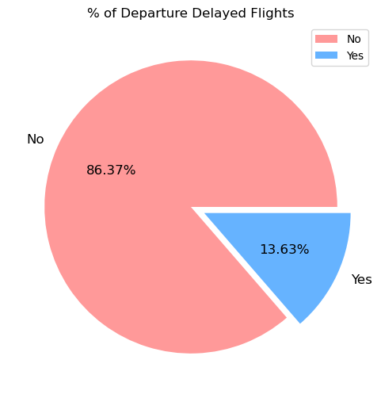

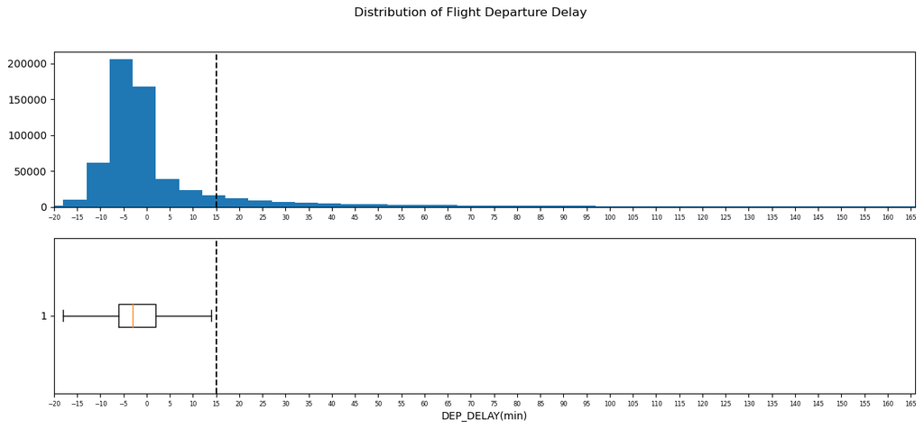

## Distribution of Flight Arrival Delay

13.73% of all flights arrived more than 15 minutes later than the scheduled time. Arrival delay has a similar distribution and a similar range, but is shifted to the left with a mean around -10 minutes (arrived 10 minutes earlier than the scheduled time).

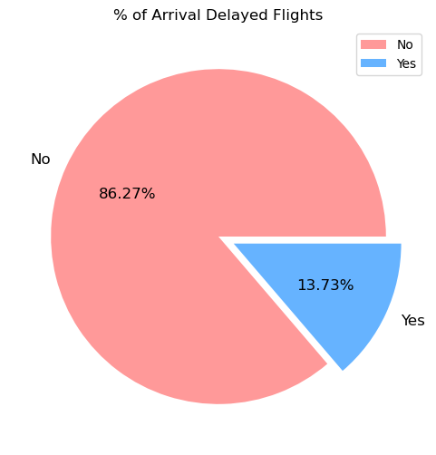

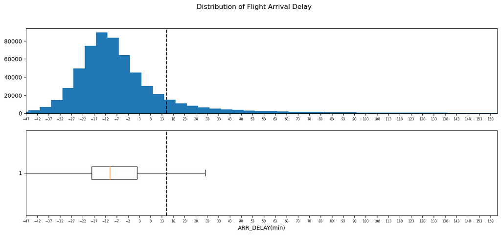